# 1. Business Context & Problem Definition

## Model Comparison Interpretation

Model performance improved as the project moved from flattened ANN models to CNN-based transfer learning. The largest improvement came from using VGG16, confirming that spatial feature extraction is essential for MRI classification.

The best overall model was Model 4B, which combined a VGG16 feature extractor, a custom feedforward classifier head, and fine-tuning of later convolutional layers. Although the augmented model was also strong, it did not outperform Model 4B on the final test set.

```python
import numpy as np
import torch
import matplotlib.pyplot as plt
from sklearn.metrics import f1_score, confusion_matrix, classification_report

def evaluate_and_report(model, loader, title="Model"):
    model.to(DEVICE)
    model.eval()
    all_y, all_pred = [], []

    with torch.no_grad():
        for x, y in loader:
            x = x.to(DEVICE)
            logits = model(x)
            preds = torch.argmax(logits, dim=1).cpu().numpy()
            all_pred.append(preds)
            all_y.append(y.numpy())

    y_true = np.concatenate(all_y)
    y_pred = np.concatenate(all_pred)

    acc = (y_true == y_pred).mean()
    macro_f1 = f1_score(y_true, y_pred, average="macro")

    print(f"{title}")
    print(f"Accuracy: {acc:.4f}")
    print(f"Macro F1: {macro_f1:.4f}\n")
    print(classification_report(y_true, y_pred, target_names=CLASS_NAMES))

    cm = confusion_matrix(y_true, y_pred)
    plt.figure(figsize=(6,5))
    plt.imshow(cm)
    plt.title(f"Confusion Matrix - {title}")
    plt.xlabel("Predicted")
    plt.ylabel("True")
    plt.xticks(range(len(CLASS_NAMES)), CLASS_NAMES, rotation=45, ha="right")
    plt.yticks(range(len(CLASS_NAMES)), CLASS_NAMES)
    plt.colorbar()
    for i in range(cm.shape[0]):
        for j in range(cm.shape[1]):
            plt.text(j, i, cm[i, j], ha="center", va="center")
    plt.tight_layout()
    plt.show()

    return acc, macro_f1, cm
```

```
Model 4B (VGG16 + FF + Fine-tune)
Accuracy: 0.9517
Macro F1: 0.9483

              precision    recall  f1-score   support

      glioma       0.99      0.87      0.92        97
  meningioma       0.86      0.96      0.90        99
   pituitary       0.96      0.97      0.97       113
     notumor       1.00      0.99      1.00       126

    accuracy                           0.95       435
   macro avg       0.95      0.95      0.95       435
weighted avg       0.96      0.95      0.95       435
```

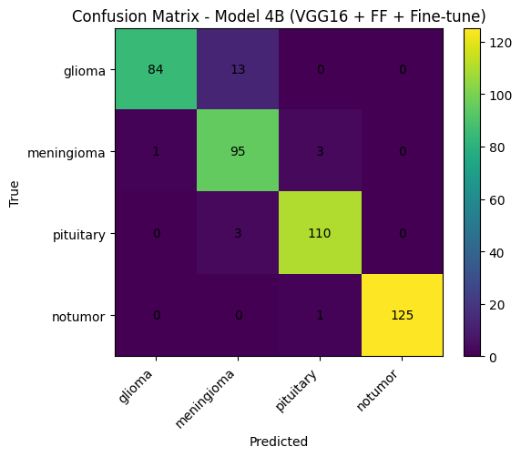

```
Model 5B (VGG16 + FF + Aug + Fine-tune)
Accuracy: 0.9448
Macro F1: 0.9401

              precision    recall  f1-score   support

      glioma       0.90      0.93      0.91        97
  meningioma       0.90      0.87      0.88        99
   pituitary       0.96      0.96      0.96       113
     notumor       1.00      1.00      1.00       126

    accuracy                           0.94       435
   macro avg       0.94      0.94      0.94       435
weighted avg       0.94      0.94      0.94       435
```

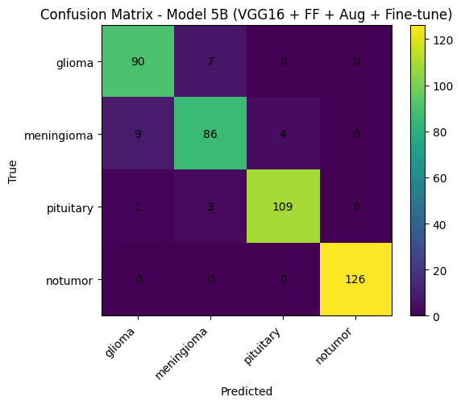

```python
acc4, f14, cm4 = evaluate_and_report(vgg4, test_loader, title="Model 4B (VGG16 + FF + Fine-tune)")


acc5, f15, cm5 = evaluate_and_report(vgg5, test_loader, title="Model 5B (VGG16 + FF + Aug + Fine-tune)")
```

# Confusion Matrix Insights

# Business Insights & Recommendations

### 1. Spatial learning is critical

Flattened ANN models underperformed compared to CNN-based models, demonstrating that preserving spatial relationships in MRI images is essential for accurate tumor classification.

### 2. Transfer learning is highly effective

Using a pretrained VGG16 model significantly improved performance. Fine-tuning the last convolutional block allowed the model to adapt general visual features to MRI-specific patterns.

### 4. Most challenging distinction: Glioma vs Meningioma

Some misclassifications occurred between glioma and meningioma, which aligns with known clinical similarities in appearance. Additional domain-specific data or multi-sequence MRI inputs may further improve performance.

## Future improvements may include:

- Multi-sequence MRI inputs
- Attention-based models
- Larger datasets

# Conclusion

## Portfolio Summary

This project demonstrates a complete applied deep learning workflow for medical image classification. The final model achieved strong multi-class performance and showed that CNN-based transfer learning is significantly more effective than traditional flattened ANN models for MRI image analysis.

The project also highlights important real-world machine learning considerations, including class balance, preprocessing consistency, artifact risk, model comparison, and final test-set evaluation.

Future improvements could include using a larger clinical dataset, testing additional CNN architectures, applying explainability methods such as Grad-CAM, and validating the model on MRI scans from external sources.